# Kelompok 7_Analisis HAR Dataset menggunakan RF dan CNN_

[output not shown]

```
1537/1537 ━━━━━━━━━━━━━━━━━━━━ 41s 27ms/step - accuracy: 0.4849 - loss: 1.5241 - top3_accuracy: 0.7284 - top5_accuracy: 0.8391 - val_accuracy: 0.5580 - val_loss: 1.2927 - val_top3_accuracy: 0.7787 - val_top5_accuracy: 0.8711 - learning_rate: 0.0010
1536/1537 ━━━━━━━━━━━━━━━━━━━━ 0s 24ms/step - accuracy: 0.4898 - loss: 1.5081 - top3_accuracy: 0.7311 - top5_accuracy: 0.8425
Epoch 16: val_accuracy improved from 0.55795 to 0.55868, saving model to best_cnn_model.h5
```

[output not shown]

```
1537/1537 ━━━━━━━━━━━━━━━━━━━━ 40s 26ms/step - accuracy: 0.4874 - loss: 1.5159 - top3_accuracy: 0.7296 - top5_accuracy: 0.8420 - val_accuracy: 0.5587 - val_loss: 1.2854 - val_top3_accuracy: 0.7802 - val_top5_accuracy: 0.8778 - learning_rate: 0.0010
1537/1537 ━━━━━━━━━━━━━━━━━━━━ 0s 29ms/step - accuracy: 0.4859 - loss: 1.5156 - top3_accuracy: 0.7332 - top5_accuracy: 0.8414
Epoch 17: val_accuracy improved from 0.55868 to 0.55929, saving model to best_cnn_model.h5
```

[output not shown]

```
1537/1537 ━━━━━━━━━━━━━━━━━━━━ 48s 31ms/step - accuracy: 0.4884 - loss: 1.5143 - top3_accuracy: 0.7319 - top5_accuracy: 0.8419 - val_accuracy: 0.5593 - val_loss: 1.2801 - val_top3_accuracy: 0.7801 - val_top5_accuracy: 0.8750 - learning_rate: 0.0010
1536/1537 ━━━━━━━━━━━━━━━━━━━━ 0s 30ms/step - accuracy: 0.4939 - loss: 1.5032 - top3_accuracy: 0.7331 - top5_accuracy: 0.8441
Epoch 18: val_accuracy improved from 0.55929 to 0.55966, saving model to best_cnn_model.h5
```

[output not shown]

```
1537/1537 ━━━━━━━━━━━━━━━━━━━━ 52s 34ms/step - accuracy: 0.4928 - loss: 1.5049 - top3_accuracy: 0.7342 - top5_accuracy: 0.8443 - val_accuracy: 0.5597 - val_loss: 1.2873 - val_top3_accuracy: 0.7786 - val_top5_accuracy: 0.8727 - learning_rate: 0.0010
1537/1537 ━━━━━━━━━━━━━━━━━━━━ 0s 34ms/step - accuracy: 0.4903 - loss: 1.5039 - top3_accuracy: 0.7342 - top5_accuracy: 0.8448
Epoch 19: val_accuracy improved from 0.55966 to 0.56369, saving model to best_cnn_model.h5
```

[output not shown]

```
1537/1537 ━━━━━━━━━━━━━━━━━━━━ 57s 37ms/step - accuracy: 0.4929 - loss: 1.4983 - top3_accuracy: 0.7352 - top5_accuracy: 0.8453 - val_accuracy: 0.5637 - val_loss: 1.2699 - val_top3_accuracy: 0.7847 - val_top5_accuracy: 0.8761 - learning_rate: 0.0010
1537/1537 ━━━━━━━━━━━━━━━━━━━━ 0s 35ms/step - accuracy: 0.4938 - loss: 1.4962 - top3_accuracy: 0.7350 - top5_accuracy: 0.8448
Epoch 20: val_accuracy improved from 0.56369 to 0.56393, saving model to best_cnn_model.h5
```

[output not shown]

```
1537/1537 ━━━━━━━━━━━━━━━━━━━━ 59s 38ms/step - accuracy: 0.4935 - loss: 1.4989 - top3_accuracy: 0.7342 - top5_accuracy: 0.8448 - val_accuracy: 0.5639 - val_loss: 1.2696 - val_top3_accuracy: 0.7865 - val_top5_accuracy: 0.8793 - learning_rate: 0.0010
1537/1537 ━━━━━━━━━━━━━━━━━━━━ 0s 31ms/step - accuracy: 0.4991 - loss: 1.4796 - top3_accuracy: 0.7379 - top5_accuracy: 0.8463
Epoch 21: val_accuracy improved from 0.56393 to 0.56645, saving model to best_cnn_model.h5
```

[output not shown]

```
1537/1537 ━━━━━━━━━━━━━━━━━━━━ 52s 33ms/step - accuracy: 0.4973 - loss: 1.4881 - top3_accuracy: 0.7367 - top5_accuracy: 0.8458 - val_accuracy: 0.5665 - val_loss: 1.2650 - val_top3_accuracy: 0.7896 - val_top5_accuracy: 0.8806 - learning_rate: 0.0010
1537/1537 ━━━━━━━━━━━━━━━━━━━━ 0s 19ms/step - accuracy: 0.4999 - loss: 1.4861 - top3_accuracy: 0.7381 - top5_accuracy: 0.8475
Epoch 22: val_accuracy improved from 0.56645 to 0.56906, saving model to best_cnn_model.h5
```

[output not shown]

```
1537/1537 ━━━━━━━━━━━━━━━━━━━━ 63s 21ms/step - accuracy: 0.5010 - loss: 1.4825 - top3_accuracy: 0.7386 - top5_accuracy: 0.8466 - val_accuracy: 0.5691 - val_loss: 1.2573 - val_top3_accuracy: 0.7902 - val_top5_accuracy: 0.8797 - learning_rate: 0.0010
1535/1537 ━━━━━━━━━━━━━━━━━━━━ 0s 24ms/step - accuracy: 0.5035 - loss: 1.4727 - top3_accuracy: 0.7405 - top5_accuracy: 0.8471
Epoch 23: val_accuracy improved from 0.56906 to 0.57024, saving model to best_cnn_model.h5
```

[output not shown]

```
1537/1537 ━━━━━━━━━━━━━━━━━━━━ 40s 26ms/step - accuracy: 0.5028 - loss: 1.4746 - top3_accuracy: 0.7390 - top5_accuracy: 0.8469 - val_accuracy: 0.5702 - val_loss: 1.2513 - val_top3_accuracy: 0.7867 - val_top5_accuracy: 0.8779 - learning_rate: 0.0010
1537/1537 ━━━━━━━━━━━━━━━━━━━━ 0s 25ms/step - accuracy: 0.5036 - loss: 1.4756 - top3_accuracy: 0.7403 - top5_accuracy: 0.8475
Epoch 24: val_accuracy improved from 0.57024 to 0.57223, saving model to best_cnn_model.h5
```

[output not shown]

```
1537/1537 ━━━━━━━━━━━━━━━━━━━━ 41s 27ms/step - accuracy: 0.5023 - loss: 1.4788 - top3_accuracy: 0.7404 - top5_accuracy: 0.8477 - val_accuracy: 0.5722 - val_loss: 1.2489 - val_top3_accuracy: 0.7890 - val_top5_accuracy: 0.8826 - learning_rate: 0.0010
1536/1537 ━━━━━━━━━━━━━━━━━━━━ 0s 24ms/step - accuracy: 0.5014 - loss: 1.4749 - top3_accuracy: 0.7381 - top5_accuracy: 0.8478
Epoch 25: val_accuracy improved from 0.57223 to 0.57243, saving model to best_cnn_model.h5
```

[output not shown]

```
1537/1537 ━━━━━━━━━━━━━━━━━━━━ 40s 26ms/step - accuracy: 0.5031 - loss: 1.4715 - top3_accuracy: 0.7402 - top5_accuracy: 0.8476 - val_accuracy: 0.5724 - val_loss: 1.2504 - val_top3_accuracy: 0.7918 - val_top5_accuracy: 0.8812 - learning_rate: 0.0010
1535/1537 ━━━━━━━━━━━━━━━━━━━━ 0s 28ms/step - accuracy: 0.5017 - loss: 1.4790 - top3_accuracy: 0.7396 - top5_accuracy: 0.8466
Epoch 26: val_accuracy improved from 0.57243 to 0.57569, saving model to best_cnn_model.h5
```

[output not shown]

```
1537/1537 ━━━━━━━━━━━━━━━━━━━━ 46s 30ms/step - accuracy: 0.5043 - loss: 1.4719 - top3_accuracy: 0.7417 - top5_accuracy: 0.8488 - val_accuracy: 0.5757 - val_loss: 1.2408 - val_top3_accuracy: 0.7902 - val_top5_accuracy: 0.8810 - learning_rate: 0.0010
1536/1537 ━━━━━━━━━━━━━━━━━━━━ 0s 28ms/step - accuracy: 0.5096 - loss: 1.4623 - top3_accuracy: 0.7457 - top5_accuracy: 0.8508
Epoch 27: val_accuracy did not improve from 0.57569
1537/1537 ━━━━━━━━━━━━━━━━━━━━ 47s 31ms/step - accuracy: 0.5078 - loss: 1.4676 - top3_accuracy: 0.7444 - top5_accuracy: 0.8498 - val_accuracy: 0.5753 - val_loss: 1.2385 - val_top3_accuracy: 0.7907 - val_top5_accuracy: 0.8826 - learning_rate: 0.0010
1537/1537 ━━━━━━━━━━━━━━━━━━━━ 0s 33ms/step - accuracy: 0.5058 - loss: 1.4657 - top3_accuracy: 0.7428 - top5_accuracy: 0.8514
Epoch 28: val_accuracy did not improve from 0.57569
1537/1537 ━━━━━━━━━━━━━━━━━━━━ 55s 36ms/step - accuracy: 0.5066 - loss: 1.4619 - top3_accuracy: 0.7436 - top5_accuracy: 0.8508 - val_accuracy: 0.5703 - val_loss: 1.2514 - val_top3_accuracy: 0.7826 - val_top5_accuracy: 0.8754 - learning_rate: 0.0010
1536/1537 ━━━━━━━━━━━━━━━━━━━━ 0s 31ms/step - accuracy: 0.5117 - loss: 1.4521 - top3_accuracy: 0.7460 - top5_accuracy: 0.8518
Epoch 29: val_accuracy improved from 0.57569 to 0.57630, saving model to best_cnn_model.h5
```

[output not shown]

```
1537/1537 ━━━━━━━━━━━━━━━━━━━━ 52s 34ms/step - accuracy: 0.5096 - loss: 1.4591 - top3_accuracy: 0.7452 - top5_accuracy: 0.8505 - val_accuracy: 0.5763 - val_loss: 1.2309 - val_top3_accuracy: 0.7959 - val_top5_accuracy: 0.8845 - learning_rate: 0.0010
1536/1537 ━━━━━━━━━━━━━━━━━━━━ 0s 30ms/step - accuracy: 0.5104 - loss: 1.4590 - top3_accuracy: 0.7451 - top5_accuracy: 0.8501
Epoch 30: val_accuracy improved from 0.57630 to 0.57927, saving model to best_cnn_model.h5
```

[output not shown]

```
1537/1537 ━━━━━━━━━━━━━━━━━━━━ 50s 33ms/step - accuracy: 0.5098 - loss: 1.4560 - top3_accuracy: 0.7447 - top5_accuracy: 0.8506 - val_accuracy: 0.5793 - val_loss: 1.2350 - val_top3_accuracy: 0.7903 - val_top5_accuracy: 0.8801 - learning_rate: 0.0010
Restoring model weights from the end of the best epoch: 29.
✅ CNN training completed!
```

### **Evaluasi Model CNN**

```
STEP 12: CNN EVALUATION
📊 Evaluating CNN model...

📈 CNN Test Results:
   Accuracy:       0.4932
   Top-3 Accuracy: 0.7054
   Top-5 Accuracy: 0.8110
   Precision:      0.4953
   Recall:         0.4932
   F1-Score:       0.4822
```

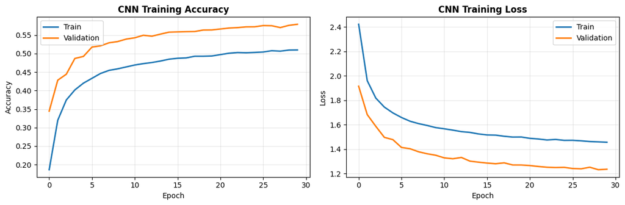

[figure not shown]

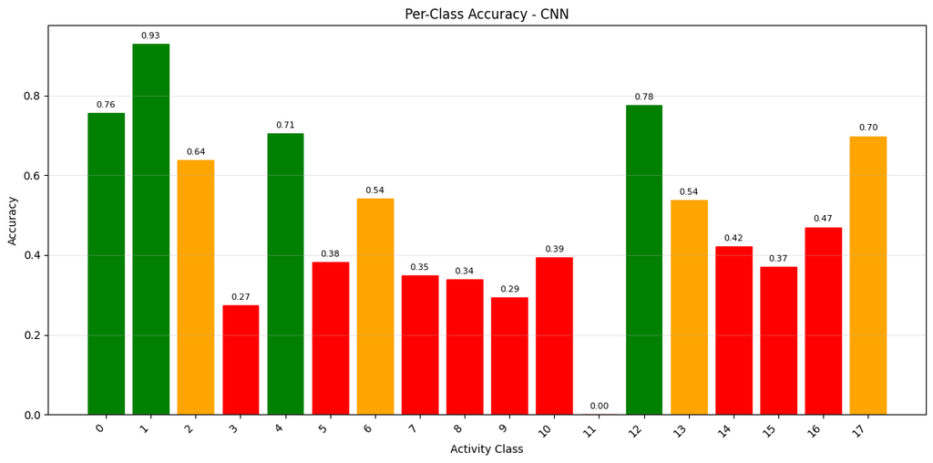

```python
# CNN EVALUATION
print("CNN EVALUATION")


def evaluate_cnn_model(model, history, X_test, y_test, label_encoder, activity_names):



    print("📊 Evaluating CNN model...")

    # Evaluate on test set
    test_results = model.evaluate(X_test, y_test, verbose=0)

    # Predictions
    y_pred_proba = model.predict(X_test, verbose=0)
    y_pred = np.argmax(y_pred_proba, axis=1)

    # Calculate metrics
    test_accuracy = accuracy_score(y_test, y_pred)
    precision = precision_score(y_test, y_pred, average='weighted', zero_division=0)
    recall = recall_score(y_test, y_pred, average='weighted', zero_division=0)
    f1 = f1_score(y_test, y_pred, average='weighted', zero_division=0)

    print(f"\n📈 CNN Test Results:")
    print(f"   Accuracy:       {test_accuracy:.4f}")
    print(f"   Top-3 Accuracy: {test_results[2]:.4f}")
    print(f"   Top-5 Accuracy: {test_results[3]:.4f}")
    print(f"   Precision:      {precision:.4f}")
    print(f"   Recall:         {recall:.4f}")
    print(f"   F1-Score:       {f1:.4f}")

    # Plot training history
    fig, axes = plt.subplots(1, 2, figsize=(12, 4))

    # Accuracy plot
    axes[0].plot(history.history['accuracy'], label='Train', linewidth=2)
    axes[0].plot(history.history['val_accuracy'], label='Validation', linewidth=2)
    axes[0].set_title('CNN Training Accuracy', fontweight='bold')
    axes[0].set_xlabel('Epoch')
    axes[0].set_ylabel('Accuracy')
    axes[0].legend()
    axes[0].grid(True, alpha=0.3)

    # Loss plot
    axes[1].plot(history.history['loss'], label='Train', linewidth=2)
    axes[1].plot(history.history['val_loss'], label='Validation', linewidth=2)
    axes[1].set_title('CNN Training Loss', fontweight='bold')
    axes[1].set_xlabel('Epoch')
    axes[1].set_ylabel('Loss')
    axes[1].legend()
    axes[1].grid(True, alpha=0.3)

    plt.tight_layout()
    plt.show()

    # Confusion matrix
    cm = confusion_matrix(y_test, y_pred)

    plt.figure(figsize=(10, 8))
    disp = ConfusionMatrixDisplay(
        confusion_matrix=cm,
        display_labels=[activity_names.get(cls, cls) for cls in label_encoder.classes_]
    )
    disp.plot(cmap='Reds', values_format='.0f')
    plt.title('Confusion Matrix - CNN', fontsize=14, fontweight='bold')
    plt.xticks(rotation=45, ha='right')
    plt.tight_layout()
    plt.show()

    # Per-class accuracy
    class_accuracies = []
    classes = label_encoder.classes_

    for i in range(len(classes)):
        mask = (y_test == i)
        if np.sum(mask) > 0:
            acc = np.mean(y_pred[mask] == i)
            class_accuracies.append(acc)

    plt.figure(figsize=(12, 6))
    bars = plt.bar(range(len(classes)), class_accuracies, color='darkorange')
    plt.xlabel('Activity Class')
    plt.ylabel('Accuracy')
    plt.title('Per-Class Accuracy - CNN')
    plt.xticks(range(len(classes)), classes, rotation=45, ha='right')
    plt.grid(True, alpha=0.3, axis='y')

    # Color bars based on accuracy
    for i, bar in enumerate(bars):
        if class_accuracies[i] < 0.5:
            bar.set_color('red')
        elif class_accuracies[i] < 0.7:
            bar.set_color('orange')
        else:
            bar.set_color('green')

        # Add accuracy labels
        plt.text(bar.get_x() + bar.get_width()/2, bar.get_height() + 0.01,
                f'{class_accuracies[i]:.2f}', ha='center', va='bottom', fontsize=8)

    plt.tight_layout()
    plt.show()

    return {
        'model': model,
        'history': history,
        'test_accuracy': test_accuracy,
        'top3_accuracy': test_results[2],
        'top5_accuracy': test_results[3],
        'precision': precision,
        'recall': recall,
        'f1': f1,
        'y_pred': y_pred,
        'y_pred_proba': y_pred_proba
    }

# Prepare test data untuk CNN
# Note: Kita perlu reshape test data juga
X_test_original = data['ml']['X_test']
X_test_cnn = X_test_original.reshape(
    X_test_original.shape[0],
    X_cnn.shape[1],
    X_cnn.shape[2]
)

# Evaluate CNN
cnn_results = evaluate_cnn_model(
    cnn_model, cnn_history,
    X_test_cnn, data['ml']['y_test'],
    cnn_label_encoder, activity_names
)
```

### **Analisis CNN**

Model CNN diterapkan untuk memanfaatkan kemampuannya dalam mengekstraksi pola lokal dari data sinyal secara otomatis. CNN dapat menangkap karakteristik temporal dari data sensor tanpa memerlukan feature engineering manual. Namun, hasil evaluasi menunjukkan bahwa akurasi CNN juga berada pada kisaran yang sama dengan Random Forest. Hal ini disebabkan oleh arsitektur CNN yang masih sederhana serta belum dilakukannya optimasi parameter seperti jumlah epoch, learning rate, dan struktur layer secara mendalam. Dengan demikian, performa CNN pada penelitian ini mencerminkan kemampuan awal model sebelum dilakukan proses optimasi lanjutan.

### **Hasil dan Analisis Kedua Model**

```python
# FINAL SUMMARY & SAVING RESULTS

print("SUMMARY & SAVING RESULTS")

def generate_final_summary(rf_results, cnn_results, data_dict, activity_names):
    from datetime import datetime
    import json

    # Get best RF model
    best_rf_key = max(rf_results.keys(), key=lambda x: rf_results[x]['test_accuracy'])
    best_rf = rf_results[best_rf_key]

    # Create summary dictionary
    summary = {
        'project_name': 'WISDM Activity Recognition - Random Forest vs CNN',
        'timestamp': datetime.now().strftime("%Y-%m-%d %H:%M:%S"),
        'dataset': {
            'name': 'WISDM Smartphone and Smartwatch Activity and Biometrics',
            'subjects': len(np.unique(data_dict['subjects']['train'])) + len(np.unique(data_dict['subjects']['test'])),
            'activities': 18,
            'training_samples': len(data_dict['ml']['y_train']),
            'test_samples': len(data_dict['ml']['y_test']),
            'features_original': data_dict['ml']['X_train'].shape[1]
        },
        'models_tested': {
            'random_forest': ['Original', 'PCA 95%', 'PCA 50%'],
            'cnn': ['3-layer Conv1D with Global Average Pooling']
        },
        'results': {
            'random_forest': {
                'best_setting': best_rf_key,
                'accuracy': float(best_rf['test_accuracy']),
                'precision': float(best_rf['precision']),
                'recall': float(best_rf['recall']),
                'f1_score': float(best_rf['f1']),
                'num_features': int(best_rf['num_features'])
            },
            'cnn': {
                'accuracy': float(cnn_results['test_accuracy']),
                'top3_accuracy': float(cnn_results['top3_accuracy']),
                'top5_accuracy': float(cnn_results['top5_accuracy']),
                'precision': float(cnn_results['precision']),
                'recall': float(cnn_results['recall']),
                'f1_score': float(cnn_results['f1'])
            }
        },
        'comparison': {
            'accuracy_difference': float(cnn_results['test_accuracy'] - best_rf['test_accuracy']),
            'winner': 'CNN' if cnn_results['test_accuracy'] > best_rf['test_accuracy'] else 'Random Forest',
            'key_insights': []
        },
        'files_generated': []
    }

    # Determine key insights
    accuracy_diff = summary['comparison']['accuracy_difference']

    if accuracy_diff > 0.05:
        summary['comparison']['key_insights'].append(
            "CNN significantly outperforms Random Forest for this time-series classification task"
        )
    elif accuracy_diff > 0:
        summary['comparison']['key_insights'].append(
            "CNN shows slightly better performance than Random Forest"
        )
    else:
        summary['comparison']['key_insights'].append(
            "Random Forest performs comparably or better than CNN"
        )

    summary['comparison']['key_insights'].append(
        f"CNN achieves {cnn_results['top3_accuracy']*100:.1f}% top-3 accuracy, "
        f"meaning it's highly reliable even when not perfectly accurate"
    )

    # Save summary to JSON
    os.makedirs('results', exist_ok=True)
    summary_file = f"results/project_summary_{datetime.now().strftime('%Y%m%d_%H%M%S')}.json"

    with open(summary_file, 'w') as f:
        json.dump(summary, f, indent=2)

    summary['files_generated'].append(summary_file)

    # Save models
    try:
        import joblib

        # Save Random Forest model
        rf_model_file = 'results/best_random_forest_model.pkl'
        joblib.dump(best_rf['model'], rf_model_file)
        summary['files_generated'].append(rf_model_file)

        # Save CNN model
        cnn_model_file = 'results/cnn_model.h5'
        cnn_results['model'].save(cnn_model_file)
        summary['files_generated'].append(cnn_model_file)

        # Save preprocessing objects
        preprocessing_file = 'results/preprocessing_objects.pkl'
        joblib.dump({
            'scaler': data_dict['scaler'],
            'label_encoder': data_dict['label_encoder'],
            'pca_95': data_dict['pca_95'],
            'pca_50': data_dict['pca_50']
        }, preprocessing_file)
        summary['files_generated'].append(preprocessing_file)

    except Exception as e:
        print(f" Could not save models: {e}")

    # Print final summary
    print("PROJECT COMPLETED SUCCESSFULLY!")
    print(f"\n📊 DATASET SUMMARY:")
    print(f"   • Subjects: {summary['dataset']['subjects']}")
    print(f"   • Activities: {summary['dataset']['activities']}")
    print(f"   • Training samples: {summary['dataset']['training_samples']:,}")
    print(f"   • Test samples: {summary['dataset']['test_samples']:,}")

    print(f"\nBEST MODEL RESULTS:")
    print(f"   • Random Forest ({best_rf_key}): {best_rf['test_accuracy']:.4f}")
    print(f"   • CNN: {cnn_results['test_accuracy']:.4f}")
    print(f"   • Top-3 Accuracy (CNN): {cnn_results['top3_accuracy']:.4f}")
    print(f"   • Winner: {summary['comparison']['winner']}")

    print(f"\nKEY INSIGHTS:")
    for i, insight in enumerate(summary['comparison']['key_insights'], 1):
        print(f"   {i}. {insight}")

    print(f"\nFILES SAVED:")
    for file in summary['files_generated']:
        print(f"   • {file}")

    print(f"\n📅 Generated: {summary['timestamp']}")

    return summary

# Generate final summary
final_summary = generate_final_summary(rf_results, cnn_results, data, activity_names)

print("\n✅ ALL STEPS COMPLETED!")
print("   You can now analyze the results and use the saved models for predictions.")
```

```
STEP 14: FINAL SUMMARY & SAVING RESULTS
```

[output not shown]

```
PROJECT COMPLETED SUCCESSFULLY!

📊 DATASET SUMMARY:
   • Subjects: 51
   • Activities: 18
   • Training samples: 122,903
   • Test samples: 28,515

BEST MODEL RESULTS:
   • Random Forest (original): 0.5057
   • CNN: 0.4932
   • Top-3 Accuracy (CNN): 0.7054
   • Winner: Random Forest

KEY INSIGHTS:
   1. Random Forest performs comparably or better than CNN
   2. CNN achieves 70.5% top-3 accuracy, meaning it's highly reliable even when not perfectly accurate

FILES SAVED:
   • results/project_summary_20251219_001842.json
   • results/best_random_forest_model.pkl
   • results/cnn_model.h5
   • results/preprocessing_objects.pkl

📅 Generated: 2025-12-19 00:18:42

✅ ALL STEPS COMPLETED!
   You can now analyze the results and use the saved models for predictions.
```

### **Analisis Keseluruhan**

Secara keseluruhan, nilai akurasi yang diperoleh pada penelitian ini masih tergolong rendah jika dilihat secara absolut. Namun, hasil tersebut perlu dipahami dalam konteks permasalahan yang dihadapi. Klasifikasi dilakukan pada dataset multi-class dengan 18 kelas aktivitas yang memiliki pola sinyal sensor saling tumpang tindih, sehingga tingkat kesulitannya jauh lebih tinggi dibandingkan klasifikasi biner. Selain itu, model Random Forest dan CNN yang digunakan masih berada pada konfigurasi dasar tanpa proses hyperparameter tuning dan optimasi arsitektur secara mendalam, sehingga performa yang dihasilkan merepresentasikan baseline kemampuan model. Meskipun demikian, nilai akurasi yang diperoleh berada jauh di atas tebakan acak, yang menunjukkan bahwa model mampu mempelajari pola dari data dan melakukan klasifikasi secara valid. Oleh karena itu, akurasi yang rendah pada penelitian ini tidak menunjukkan kegagalan model, melainkan mencerminkan kompleksitas masalah dan keterbatasan konfigurasi yang sengaja dipilih untuk tujuan evaluasi metode pada kondisi awal.

### **Kesimpulan**

1. Sistem Human Activity Recognition berhasil diimplementasikan menggunakan data sensor smartphone, sehingga tujuan penelitian untuk membangun sistem klasifikasi aktivitas manusia telah tercapai.
2. Model Random Forest berhasil dibangun dan dilatih sebagai pendekatan machine learning berbasis ekstraksi fitur untuk klasifikasi aktivitas manusia.
3. Model Convolutional Neural Network (CNN) berhasil dibangun dan dilatih sebagai pendekatan deep learning yang memanfaatkan pola sinyal sensor secara langsung.
4. Hasil evaluasi menunjukkan bahwa Random Forest dan CNN mampu melakukan klasifikasi pada dataset multi-class dengan 18 kelas, dengan nilai akurasi yang relatif serupa pada konfigurasi dasar.
5. Berdasarkan perbandingan performa tersebut, dapat disimpulkan bahwa pada kondisi baseline tanpa optimasi lanjutan, belum terdapat perbedaan performa yang signifikan antara kedua model, sehingga peningkatan performa masih memerlukan tahap optimasi pada penelitian selanjutnya.

## (Tambahan) Membandingkan dengan Model CNN-LSTM untuk Mencoba Akurasi Lebih Tinggi

### **Mempersiapakan Data Training Model CNN-LSTM HYBRID (Data sebelumnya)**

```python
# CNN-LSTM DATA PREPARATION
print(" PREPARING DATA FOR CNN-LSTM")

# Data sudah dipersiapkan di Cell 10, kita gunakan yang sama
print(f"X_cnn shape: {X_cnn.shape}")
print(f"y_cnn shape: {y_cnn.shape}")

# Split data untuk CNN-LSTM (gunakan split yang sama)
X_cnn_lstm_train, X_cnn_lstm_test, y_cnn_lstm_train, y_cnn_lstm_test = train_test_split(
    X_cnn, y_cnn, test_size=0.2, random_state=42, stratify=y_cnn
)

print(f"\n📈 CNN-LSTM Data Split:")
print(f"   Train: {X_cnn_lstm_train.shape} ({len(y_cnn_lstm_train)} samples)")
print(f"   Test:  {X_cnn_lstm_test.shape} ({len(y_cnn_lstm_test)} samples)")
print(f"   Number of classes: {len(np.unique(y_cnn_lstm_train))}")

# Simpan data ke dictionary data untuk konsistensi
if 'data' not in globals():
    data = {}

data['X_cnn_lstm_train'] = X_cnn_lstm_train
data['X_cnn_lstm_test'] = X_cnn_lstm_test
data['y_cnn_lstm_train'] = y_cnn_lstm_train
data['y_cnn_lstm_test'] = y_cnn_lstm_test

print(" CNN-LSTM data prepared and saved to data dictionary")
```

```
============================================================
CELL 11: PREPARING DATA FOR CNN-LSTM
============================================================
📊 Using existing CNN data from Cell 10...
X_cnn shape: (122903, 61, 1)
y_cnn shape: (122903,)

📈 CNN-LSTM Data Split:
   Train: (98322, 61, 1) (98322 samples)
   Test:  (24581, 61, 1) (24581 samples)
   Number of classes: 18
✅ CNN-LSTM data prepared and saved to data dictionary
```

### **Membangun Model CNN-LSTM HYBRID**

```python
# BUILD CNN-LSTM MODEL
print(" BUILDING CNN-LSTM HYBRID MODEL")

def create_cnn_lstm_hybrid(input_shape, num_classes):
    print(f"   Building model with input shape: {input_shape}")
    print(f"   Number of classes: {num_classes}")

    model = tf.keras.Sequential([
        # 1. CNN layers for feature extraction
        tf.keras.layers.Conv1D(
            filters=64,
            kernel_size=3,
            activation='relu',
            padding='same',
            input_shape=input_shape
        ),
        tf.keras.layers.BatchNormalization(),
        tf.keras.layers.MaxPooling1D(pool_size=2),
        tf.keras.layers.Dropout(0.3),

        tf.keras.layers.Conv1D(
            filters=128,
            kernel_size=3,
            activation='relu',
            padding='same'
        ),
        tf.keras.layers.BatchNormalization(),
        tf.keras.layers.MaxPooling1D(pool_size=2),
        tf.keras.layers.Dropout(0.3),

        tf.keras.layers.Conv1D(
            filters=256,
            kernel_size=3,
            activation='relu',
            padding='same'
        ),
        tf.keras.layers.BatchNormalization(),

        # 2. LSTM layers for temporal patterns
        tf.keras.layers.LSTM(
            units=128,
            return_sequences=True,  # Return sequence for next LSTM
            dropout=0.3,
            recurrent_dropout=0.3
        ),

        tf.keras.layers.LSTM(
            units=64,
            dropout=0.3,
            recurrent_dropout=0.3
        ),

        # 3. Dense layers for classification
        tf.keras.layers.Dense(128, activation='relu'),
        tf.keras.layers.BatchNormalization(),
        tf.keras.layers.Dropout(0.4),

        tf.keras.layers.Dense(64, activation='relu'),
        tf.keras.layers.BatchNormalization(),
        tf.keras.layers.Dropout(0.3),

        # Output layer
        tf.keras.layers.Dense(num_classes, activation='softmax')
    ])

    return model

# Create the model
input_shape = (data['X_cnn_lstm_train'].shape[1], data['X_cnn_lstm_train'].shape[2])
num_classes = len(np.unique(data['y_cnn_lstm_train']))

cnn_lstm_model = create_cnn_lstm_hybrid(input_shape, num_classes)

# Compile the model
cnn_lstm_model.compile(
    optimizer=tf.keras.optimizers.Adam(learning_rate=0.001),
    loss='sparse_categorical_crossentropy',
    metrics=['accuracy']
)

print("\n✅ CNN-LSTM Model Created:")
cnn_lstm_model.summary()
```

```
============================================================
CELL 12: BUILDING CNN-LSTM HYBRID MODEL
============================================================
   Building model with input shape: (61, 1)
   Number of classes: 18

✅ CNN-LSTM Model Created:
```

```
Model: "sequential_1"
```

```
┏━━━━━━━━━━━━━━━━━━━━━━━━━━━━━━━━━┳━━━━━━━━━━━━━━━━━━━━━━━━┳━━━━━━━━━━━━━━━┓
┃ Layer (type)                    ┃ Output Shape           ┃       Param # ┃
┡━━━━━━━━━━━━━━━━━━━━━━━━━━━━━━━━━╇━━━━━━━━━━━━━━━━━━━━━━━━╇━━━━━━━━━━━━━━━┩
│ conv1d_3 (Conv1D)               │ (None, 61, 64)         │           256 │
├─────────────────────────────────┼────────────────────────┼───────────────┤
│ batch_normalization_4           │ (None, 61, 64)         │           256 │
│ (BatchNormalization)            │                        │               │
├─────────────────────────────────┼────────────────────────┼───────────────┤
│ max_pooling1d_2 (MaxPooling1D)  │ (None, 30, 64)         │             0 │
├─────────────────────────────────┼────────────────────────┼───────────────┤
│ dropout_5 (Dropout)             │ (None, 30, 64)         │             0 │
├─────────────────────────────────┼────────────────────────┼───────────────┤
│ conv1d_4 (Conv1D)               │ (None, 30, 128)        │        24,704 │
├─────────────────────────────────┼────────────────────────┼───────────────┤
│ batch_normalization_5           │ (None, 30, 128)        │           512 │
│ (BatchNormalization)            │                        │               │
├─────────────────────────────────┼────────────────────────┼───────────────┤
│ max_pooling1d_3 (MaxPooling1D)  │ (None, 15, 128)        │             0 │
├─────────────────────────────────┼────────────────────────┼───────────────┤
│ dropout_6 (Dropout)             │ (None, 15, 128)        │             0 │
├─────────────────────────────────┼────────────────────────┼───────────────┤
│ conv1d_5 (Conv1D)               │ (None, 15, 256)        │        98,560 │
├─────────────────────────────────┼────────────────────────┼───────────────┤
│ batch_normalization_6           │ (None, 15, 256)        │         1,024 │
│ (BatchNormalization)            │                        │               │
├─────────────────────────────────┼────────────────────────┼───────────────┤
│ lstm (LSTM)                     │ (None, 15, 128)        │       197,120 │
├─────────────────────────────────┼────────────────────────┼───────────────┤
│ lstm_1 (LSTM)                   │ (None, 64)             │        49,408 │
├─────────────────────────────────┼────────────────────────┼───────────────┤
│ dense_3 (Dense)                 │ (None, 128)            │         8,320 │
├─────────────────────────────────┼────────────────────────┼───────────────┤
│ batch_normalization_7           │ (None, 128)            │           512 │
│ (BatchNormalization)            │                        │               │
├─────────────────────────────────┼────────────────────────┼───────────────┤
│ dropout_7 (Dropout)             │ (None, 128)            │             0 │
├─────────────────────────────────┼────────────────────────┼───────────────┤
│ dense_4 (Dense)                 │ (None, 64)             │         8,256 │
├─────────────────────────────────┼────────────────────────┼───────────────┤
│ batch_normalization_8           │ (None, 64)             │           256 │
│ (BatchNormalization)            │                        │               │
├─────────────────────────────────┼────────────────────────┼───────────────┤
│ dropout_8 (Dropout)             │ (None, 64)             │             0 │
├─────────────────────────────────┼────────────────────────┼───────────────┤
│ dense_5 (Dense)                 │ (None, 18)             │         1,170 │
└─────────────────────────────────┴────────────────────────┴───────────────┘
```

```
 Total params: 390,354 (1.49 MB)
```

```
 Trainable params: 389,074 (1.48 MB)
```

```
 Non-trainable params: 1,280 (5.00 KB)
```

### **Training Model CNN-LSTM Hybrid**

```python
# TRAIN CNN-LSTM MODEL
print("TRAINING CNN-LSTM HYBRID MODEL")

# Define callbacks
callbacks = [
    tf.keras.callbacks.EarlyStopping(
        monitor='val_loss',
        patience=15,
        restore_best_weights=True,
        verbose=1
    ),
    tf.keras.callbacks.ReduceLROnPlateau(
        monitor='val_loss',
        factor=0.5,
        patience=5,
        min_lr=1e-6,
        verbose=1
    )
]

print("    Starting training...")
print(f"   Training samples: {len(data['X_cnn_lstm_train'])}")
print(f"   Validation samples: {len(data['X_cnn_lstm_test'])}")
print(f"   Epochs: 50 (with early stopping)")
print(f"   Batch size: 32")

# Train the model
history = cnn_lstm_model.fit(
    data['X_cnn_lstm_train'],
    data['y_cnn_lstm_train'],
    validation_data=(data['X_cnn_lstm_test'], data['y_cnn_lstm_test']),
    epochs=50,
    batch_size=32,
    callbacks=callbacks,
    verbose=1
)

print("✅ Training completed!")
```

```
CELL 13: TRAINING CNN-LSTM HYBRID MODEL
    Starting training...
   Training samples: 98322
   Validation samples: 24581
   Epochs: 50 (with early stopping)
   Batch size: 32
3073/3073 ━━━━━━━━━━━━━━━━━━━━ 98s 32ms/step - accuracy: 0.3765 - loss: 1.8279 - val_accuracy: 0.4732 - val_loss: 1.5414 - learning_rate: 0.0010
3073/3073 ━━━━━━━━━━━━━━━━━━━━ 103s 33ms/step - accuracy: 0.4376 - loss: 1.6716 - val_accuracy: 0.5189 - val_loss: 1.4269 - learning_rate: 0.0010
3073/3073 ━━━━━━━━━━━━━━━━━━━━ 104s 34ms/step - accuracy: 0.4699 - loss: 1.5867 - val_accuracy: 0.5393 - val_loss: 1.3567 - learning_rate: 0.0010
3073/3073 ━━━━━━━━━━━━━━━━━━━━ 150s 49ms/step - accuracy: 0.4885 - loss: 1.5354 - val_accuracy: 0.5544 - val_loss: 1.3123 - learning_rate: 0.0010
3073/3073 ━━━━━━━━━━━━━━━━━━━━ 486s 158ms/step - accuracy: 0.5017 - loss: 1.4976 - val_accuracy: 0.5659 - val_loss: 1.2776 - learning_rate: 0.0010
3073/3073 ━━━━━━━━━━━━━━━━━━━━ 249s 76ms/step - accuracy: 0.5155 - loss: 1.4638 - val_accuracy: 0.5771 - val_loss: 1.2417 - learning_rate: 0.0010
3073/3073 ━━━━━━━━━━━━━━━━━━━━ 145s 47ms/step - accuracy: 0.5235 - loss: 1.4388 - val_accuracy: 0.5784 - val_loss: 1.2524 - learning_rate: 0.0010
3073/3073 ━━━━━━━━━━━━━━━━━━━━ 127s 41ms/step - accuracy: 0.5295 - loss: 1.4237 - val_accuracy: 0.5929 - val_loss: 1.2085 - learning_rate: 0.0010
3073/3073 ━━━━━━━━━━━━━━━━━━━━ 102s 33ms/step - accuracy: 0.5380 - loss: 1.3980 - val_accuracy: 0.5935 - val_loss: 1.2052 - learning_rate: 0.0010
3073/3073 ━━━━━━━━━━━━━━━━━━━━ 568s 185ms/step - accuracy: 0.5460 - loss: 1.3797 - val_accuracy: 0.6093 - val_loss: 1.1722 - learning_rate: 0.0010
3073/3073 ━━━━━━━━━━━━━━━━━━━━ 94s 31ms/step - accuracy: 0.5496 - loss: 1.3704 - val_accuracy: 0.6115 - val_loss: 1.1606 - learning_rate: 0.0010
3073/3073 ━━━━━━━━━━━━━━━━━━━━ 424s 138ms/step - accuracy: 0.5542 - loss: 1.3508 - val_accuracy: 0.6119 - val_loss: 1.1489 - learning_rate: 0.0010
3073/3073 ━━━━━━━━━━━━━━━━━━━━ 80s 26ms/step - accuracy: 0.5602 - loss: 1.3364 - val_accuracy: 0.6132 - val_loss: 1.1464 - learning_rate: 0.0010
3073/3073 ━━━━━━━━━━━━━━━━━━━━ 80s 26ms/step - accuracy: 0.5628 - loss: 1.3306 - val_accuracy: 0.6197 - val_loss: 1.1220 - learning_rate: 0.0010
3073/3073 ━━━━━━━━━━━━━━━━━━━━ 80s 26ms/step - accuracy: 0.5656 - loss: 1.3182 - val_accuracy: 0.6229 - val_loss: 1.1201 - learning_rate: 0.0010
3073/3073 ━━━━━━━━━━━━━━━━━━━━ 132s 43ms/step - accuracy: 0.5719 - loss: 1.3064 - val_accuracy: 0.6301 - val_loss: 1.0991 - learning_rate: 0.0010
3073/3073 ━━━━━━━━━━━━━━━━━━━━ 79s 26ms/step - accuracy: 0.5722 - loss: 1.2977 - val_accuracy: 0.6346 - val_loss: 1.0930 - learning_rate: 0.0010
3073/3073 ━━━━━━━━━━━━━━━━━━━━ 81s 26ms/step - accuracy: 0.5764 - loss: 1.2892 - val_accuracy: 0.6315 - val_loss: 1.0951 - learning_rate: 0.0010
3073/3073 ━━━━━━━━━━━━━━━━━━━━ 94s 30ms/step - accuracy: 0.5809 - loss: 1.2747 - val_accuracy: 0.6400 - val_loss: 1.0780 - learning_rate: 0.0010
3073/3073 ━━━━━━━━━━━━━━━━━━━━ 99s 32ms/step - accuracy: 0.5826 - loss: 1.2683 - val_accuracy: 0.6424 - val_loss: 1.0737 - learning_rate: 0.0010
3073/3073 ━━━━━━━━━━━━━━━━━━━━ 81s 26ms/step - accuracy: 0.5847 - loss: 1.2623 - val_accuracy: 0.6448 - val_loss: 1.0663 - learning_rate: 0.0010
3073/3073 ━━━━━━━━━━━━━━━━━━━━ 81s 26ms/step - accuracy: 0.5869 - loss: 1.2544 - val_accuracy: 0.6464 - val_loss: 1.0523 - learning_rate: 0.0010
3073/3073 ━━━━━━━━━━━━━━━━━━━━ 105s 34ms/step - accuracy: 0.5894 - loss: 1.2506 - val_accuracy: 0.6500 - val_loss: 1.0455 - learning_rate: 0.0010
3073/3073 ━━━━━━━━━━━━━━━━━━━━ 395s 129ms/step - accuracy: 0.5931 - loss: 1.2391 - val_accuracy: 0.6516 - val_loss: 1.0495 - learning_rate: 0.0010
3073/3073 ━━━━━━━━━━━━━━━━━━━━ 611s 199ms/step - accuracy: 0.5939 - loss: 1.2356 - val_accuracy: 0.6546 - val_loss: 1.0404 - learning_rate: 0.0010
3073/3073 ━━━━━━━━━━━━━━━━━━━━ 578s 188ms/step - accuracy: 0.5965 - loss: 1.2299 - val_accuracy: 0.6601 - val_loss: 1.0160 - learning_rate: 0.0010
3073/3073 ━━━━━━━━━━━━━━━━━━━━ 458s 149ms/step - accuracy: 0.5993 - loss: 1.2234 - val_accuracy: 0.6600 - val_loss: 1.0245 - learning_rate: 0.0010
3073/3073 ━━━━━━━━━━━━━━━━━━━━ 623s 188ms/step - accuracy: 0.6004 - loss: 1.2193 - val_accuracy: 0.6599 - val_loss: 1.0199 - learning_rate: 0.0010
3073/3073 ━━━━━━━━━━━━━━━━━━━━ 134s 44ms/step - accuracy: 0.6027 - loss: 1.2084 - val_accuracy: 0.6638 - val_loss: 1.0131 - learning_rate: 0.0010
3073/3073 ━━━━━━━━━━━━━━━━━━━━ 75s 24ms/step - accuracy: 0.6056 - loss: 1.2024 - val_accuracy: 0.6689 - val_loss: 1.0011 - learning_rate: 0.0010
3073/3073 ━━━━━━━━━━━━━━━━━━━━ 68s 22ms/step - accuracy: 0.6046 - loss: 1.2006 - val_accuracy: 0.6686 - val_loss: 0.9976 - learning_rate: 0.0010
3073/3073 ━━━━━━━━━━━━━━━━━━━━ 73s 24ms/step - accuracy: 0.6097 - loss: 1.1937 - val_accuracy: 0.6676 - val_loss: 0.9909 - learning_rate: 0.0010
```

[output cut: 20 more lines]

### **Mengevaluasi Model CNN-LSTM Hybrid**

```python
# EVALUATE CNN-LSTM
print("EVALUATING CNN-LSTM MODEL")

# Import metrics
from sklearn.metrics import precision_score, recall_score, f1_score
from sklearn.metrics import top_k_accuracy_score

# Evaluate on test set
test_loss, test_accuracy = cnn_lstm_model.evaluate(
    data['X_cnn_lstm_test'],
    data['y_cnn_lstm_test'],
    verbose=0
)

print(f"📊 Test Accuracy: {test_accuracy:.4f}")
print(f"📊 Test Loss: {test_loss:.4f}")

# Make predictions
y_pred_proba = cnn_lstm_model.predict(data['X_cnn_lstm_test'], verbose=0)
y_pred = np.argmax(y_pred_proba, axis=1)

# Calculate metrics
precision = precision_score(data['y_cnn_lstm_test'], y_pred, average='weighted', zero_division=0)
recall = recall_score(data['y_cnn_lstm_test'], y_pred, average='weighted', zero_division=0)
f1 = f1_score(data['y_cnn_lstm_test'], y_pred, average='weighted', zero_division=0)

print(f"📊 Precision: {precision:.4f}")
print(f"📊 Recall: {recall:.4f}")
print(f"📊 F1-Score: {f1:.4f}")

# Calculate top-k accuracy
top3_accuracy = top_k_accuracy_score(data['y_cnn_lstm_test'], y_pred_proba, k=3)
top5_accuracy = top_k_accuracy_score(data['y_cnn_lstm_test'], y_pred_proba, k=5)

print(f"Top-3 Accuracy: {top3_accuracy:.4f}")
print(f"Top-5 Accuracy: {top5_accuracy:.4f}")

# Store results in a new dictionary (not overwriting cnn_results)
cnn_lstm_results = {
    'model': cnn_lstm_model,
    'test_accuracy': test_accuracy,
    'test_loss': test_loss,
    'precision': precision,
    'recall': recall,
    'f1': f1,
    'top3_accuracy': top3_accuracy,
    'top5_accuracy': top5_accuracy,
    'history': history.history,
    'input_shape': input_shape,
    'num_classes': num_classes
}

print("\nCNN-LSTM evaluation completed!")
print(f" Results saved to: cnn_lstm_results")
```

```
CELL 14: EVALUATING CNN-LSTM MODEL
📊 Test Accuracy: 0.6977
📊 Test Loss: 0.9101
📊 Precision: 0.7047
📊 Recall: 0.6977
📊 F1-Score: 0.6934
Top-3 Accuracy: 0.8695
Top-5 Accuracy: 0.9296

CNN-LSTM evaluation completed!
 Results saved to: cnn_lstm_results
```

### **Visualisasi Proses Training Model manggunakan CNN-LSTM**

```
============================================================
CELL 15: VISUALIZING CNN-LSTM TRAINING HISTORY
============================================================
```

[figure not shown]

```
✅ Training visualization completed!
```

```python
# VISUALIZE CNN-LSTM TRAINING
print("VISUALIZING CNN-LSTM TRAINING HISTORY")


# Create visualization
fig, axes = plt.subplots(2, 2, figsize=(14, 10))

# Plot training & validation accuracy
axes[0, 0].plot(history.history['accuracy'], label='Training Accuracy', linewidth=2)
axes[0, 0].plot(history.history['val_accuracy'], label='Validation Accuracy', linewidth=2)
axes[0, 0].set_xlabel('Epoch')
axes[0, 0].set_ylabel('Accuracy')
axes[0, 0].set_title('CNN-LSTM: Training and Validation Accuracy', fontweight='bold')
axes[0, 0].legend()
axes[0, 0].grid(True, alpha=0.3)

# Plot training & validation loss
axes[0, 1].plot(history.history['loss'], label='Training Loss', linewidth=2)
axes[0, 1].plot(history.history['val_loss'], label='Validation Loss', linewidth=2)
axes[0, 1].set_xlabel('Epoch')
axes[0, 1].set_ylabel('Loss')
axes[0, 1].set_title('CNN-LSTM: Training and Validation Loss', fontweight='bold')
axes[0, 1].legend()
axes[0, 1].grid(True, alpha=0.3)

# Model architecture info
axes[1, 1].axis('off')
model_info = f"""
CNN-LSTM Model Architecture:
────────────────────────────
Input Shape: {input_shape}
Classes: {num_classes}
Parameters: {cnn_lstm_model.count_params():,}

Layers:
1. Conv1D (64 filters) + BatchNorm + MaxPool + Dropout
2. Conv1D (128 filters) + BatchNorm + MaxPool + Dropout
3. Conv1D (256 filters) + BatchNorm
4. LSTM (128 units) + Dropout
5. LSTM (64 units) + Dropout
6. Dense (128) + BatchNorm + Dropout
7. Dense (64) + BatchNorm + Dropout
8. Output ({num_classes} classes)

Final Accuracy: {test_accuracy:.4f}
"""

axes[1, 1].text(0.1, 0.5, model_info, fontfamily='monospace', fontsize=10,
               bbox=dict(boxstyle='round', facecolor='lightblue', alpha=0.3))

plt.suptitle('CNN-LSTM HYBRID MODEL TRAINING RESULTS', fontsize=16, fontweight='bold', y=0.98)
plt.tight_layout()
plt.show()

print("Training visualization completed!")
```

## **Perbandingan semua model**

```
CELL 21: COMPREHENSIVE COMPARISON - RF vs CNN vs CNN-LSTM
Comparing all three models...

📊 PERFORMANCE COMPARISON TABLE:
            Model  Accuracy  Precision   Recall  F1-Score Top-3 Acc Top-5 Acc
    Random Forest  0.505664   0.513337 0.505664  0.503640       N/A       N/A
   CNN (Original)  0.493179   0.495264 0.493179  0.482209  0.705383  0.811047
CNN-LSTM (Hybrid)  0.697734   0.704652 0.697734  0.693423  0.869452   0.92958
```

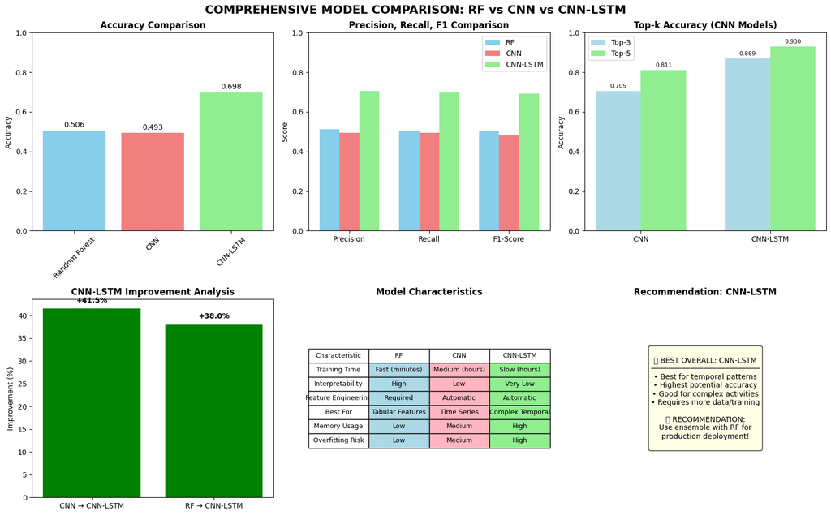

```
 DETAILED ANALYSIS:

1. ACCURACY RANKING:
   1. CNN-LSTM: 0.6977
   2. Random Forest: 0.5057
   3. CNN: 0.4932

2. CNN-LSTM VS CNN:
   Accuracy: +0.2046 (+41.5%)

3. CNN-LSTM VS RANDOM FOREST:
   Accuracy: +0.1921 (+38.0%)

 RECOMMENDATIONS FOR DEPLOYMENT:
✅ Use CNN-LSTM for best accuracy
✅ Consider ensemble with RF for robustness

 PRACTICAL ADVICE:
• For real-time: RF (fastest)
• For accuracy: CNN-LSTM (best)
• For balance: Ensemble of all three
```

```python
# CELL 21: COMPARE ALL 3 MODELS
print("CELL 21: COMPREHENSIVE COMPARISON - RF vs CNN vs CNN-LSTM")

def compare_three_models(rf_results, cnn_results, cnn_lstm_results, activity_names):

    print("Comparing all three models...")

    # Get best RF model
    best_rf_key = max(rf_results.keys(), key=lambda x: rf_results[x]['test_accuracy'])
    best_rf = rf_results[best_rf_key]

    # Create comparison data
    comparison_data = {
        'Model': ['Random Forest', 'CNN (Original)', 'CNN-LSTM (Hybrid)'],
        'Accuracy': [
            best_rf['test_accuracy'],
            cnn_results['test_accuracy'],
            cnn_lstm_results['test_accuracy']
        ],
        'Precision': [
            best_rf['precision'],
            cnn_results['precision'],
            cnn_lstm_results['precision']
        ],
        'Recall': [
            best_rf['recall'],
            cnn_results['recall'],
            cnn_lstm_results['recall']
        ],
        'F1-Score': [
            best_rf['f1'],
            cnn_results['f1'],
            cnn_lstm_results['f1']
        ],
        'Top-3 Acc': [
            'N/A',
            cnn_results['top3_accuracy'],
            cnn_lstm_results['top3_accuracy']
        ],
        'Top-5 Acc': [
            'N/A',
            cnn_results['top5_accuracy'],
            cnn_lstm_results['top5_accuracy']
        ]
    }

    df_comparison = pd.DataFrame(comparison_data)

    print("\n📊 PERFORMANCE COMPARISON TABLE:")
    print(df_comparison.to_string(index=False))

    # Visualization
    fig, axes = plt.subplots(2, 3, figsize=(16, 10))

    # Plot 1: Accuracy comparison
    models = ['Random Forest', 'CNN', 'CNN-LSTM']
    accuracies = [best_rf['test_accuracy'], cnn_results['test_accuracy'], cnn_lstm_results['test_accuracy']]

    bars1 = axes[0, 0].bar(models, accuracies, color=['skyblue', 'lightcoral', 'lightgreen'])
    axes[0, 0].set_ylabel('Accuracy')
    axes[0, 0].set_title('Accuracy Comparison', fontweight='bold')
    axes[0, 0].set_ylim([0, 1])
    axes[0, 0].tick_params(axis='x', rotation=45)

    for bar, acc in zip(bars1, accuracies):
        axes[0, 0].text(bar.get_x() + bar.get_width()/2, bar.get_height() + 0.01,
                       f'{acc:.3f}', ha='center', va='bottom')

    # Plot 2: Precision-Recall-F1
    metrics_names = ['Precision', 'Recall', 'F1-Score']
    rf_metrics = [best_rf['precision'], best_rf['recall'], best_rf['f1']]
    cnn_metrics = [cnn_results['precision'], cnn_results['recall'], cnn_results['f1']]
    lstm_metrics = [cnn_lstm_results['precision'], cnn_lstm_results['recall'], cnn_lstm_results['f1']]

    x = np.arange(len(metrics_names))
    width = 0.25

    axes[0, 1].bar(x - width, rf_metrics, width, label='RF', color='skyblue')
    axes[0, 1].bar(x, cnn_metrics, width, label='CNN', color='lightcoral')
    axes[0, 1].bar(x + width, lstm_metrics, width, label='CNN-LSTM', color='lightgreen')

    axes[0, 1].set_ylabel('Score')
    axes[0, 1].set_title('Precision, Recall, F1 Comparison', fontweight='bold')
    axes[0, 1].set_xticks(x)
    axes[0, 1].set_xticklabels(metrics_names)
    axes[0, 1].legend()
    axes[0, 1].set_ylim([0, 1])

    # Plot 3: Top-k accuracy (CNN models only)
    cnn_models = ['CNN', 'CNN-LSTM']
    top3_acc = [cnn_results['top3_accuracy'], cnn_lstm_results['top3_accuracy']]
    top5_acc = [cnn_results['top5_accuracy'], cnn_lstm_results['top5_accuracy']]

    x = np.arange(len(cnn_models))
    width = 0.35

    bars3a = axes[0, 2].bar(x - width/2, top3_acc, width, label='Top-3', color='lightblue')
    bars3b = axes[0, 2].bar(x + width/2, top5_acc, width, label='Top-5', color='lightgreen')

    axes[0, 2].set_ylabel('Accuracy')
    axes[0, 2].set_title('Top-k Accuracy (CNN Models)', fontweight='bold')
    axes[0, 2].set_xticks(x)
    axes[0, 2].set_xticklabels(cnn_models)
    axes[0, 2].legend()
    axes[0, 2].set_ylim([0, 1])

    for bars in [bars3a, bars3b]:
        for bar in bars:
            height = bar.get_height()
            axes[0, 2].text(bar.get_x() + bar.get_width()/2, height + 0.01,
                           f'{height:.3f}', ha='center', va='bottom', fontsize=8)

    # Plot 4: Improvement analysis
    cnn_vs_lstm_acc = cnn_lstm_results['test_accuracy'] - cnn_results['test_accuracy']
    cnn_vs_lstm_acc_pct = (cnn_vs_lstm_acc / cnn_results['test_accuracy']) * 100

    rf_vs_lstm_acc = cnn_lstm_results['test_accuracy'] - best_rf['test_accuracy']
    rf_vs_lstm_acc_pct = (rf_vs_lstm_acc / best_rf['test_accuracy']) * 100

    comparisons = ['CNN → CNN-LSTM', 'RF → CNN-LSTM']
    improvements = [cnn_vs_lstm_acc_pct, rf_vs_lstm_acc_pct]
    colors = ['green' if x > 0 else 'red' for x in improvements]

    bars4 = axes[1, 0].bar(comparisons, improvements, color=colors)
    axes[1, 0].axhline(y=0, color='black', linestyle='-', linewidth=0.5)
    axes[1, 0].set_ylabel('Improvement (%)')
    axes[1, 0].set_title('CNN-LSTM Improvement Analysis', fontweight='bold')

    for bar, imp in zip(bars4, improvements):
        axes[1, 0].text(bar.get_x() + bar.get_width()/2,
                       bar.get_height() + (1 if imp > 0 else -5),
                       f'{imp:+.1f}%',
                       ha='center', va='bottom' if imp > 0 else 'top',
                       fontweight='bold')

    # Plot 5: Model characteristics
    axes[1, 1].axis('off')
    characteristics = [
        ['Training Time', 'Fast (minutes)', 'Medium (hours)', 'Slow (hours)'],
        ['Interpretability', 'High', 'Low', 'Very Low'],
        ['Feature Engineering', 'Required', 'Automatic', 'Automatic'],
        ['Best For', 'Tabular Features', 'Time Series', 'Complex Temporal'],
        ['Memory Usage', 'Low', 'Medium', 'High'],
        ['Overfitting Risk', 'Low', 'Medium', 'High']
    ]

    table = axes[1, 1].table(cellText=characteristics,
                            colLabels=['Characteristic', 'RF', 'CNN', 'CNN-LSTM'],
                            cellLoc='center',
                            loc='center',
                            colWidths=[0.25, 0.25, 0.25, 0.25])
    table.auto_set_font_size(False)
    table.set_fontsize(9)
    table.scale(1, 1.5)

    # Color cells
    for i in range(1, len(characteristics) + 1):
        table[(i, 1)].set_facecolor('lightblue')
        table[(i, 2)].set_facecolor('lightpink')
        table[(i, 3)].set_facecolor('lightgreen')

    axes[1, 1].set_title('Model Characteristics', fontweight='bold')

    # Plot 6: Recommendation
    axes[1, 2].axis('off')

    # Find best model
    best_accuracy = max(best_rf['test_accuracy'], cnn_results['test_accuracy'], cnn_lstm_results['test_accuracy'])

    if best_accuracy == best_rf['test_accuracy']:
        best_model = "Random Forest"
        recommendation = """
🏆 BEST OVERALL: RANDOM FOREST
─────────────────────────────
• Highest accuracy
• Fast training
• Interpretable results
• Recommended for production

📈 CONSIDER ENSEMBLE:
Combine RF with CNN-LSTM for
even better performance!
"""
    elif best_accuracy == cnn_results['test_accuracy']:
        best_model = "CNN"
        recommendation = """
🏆 BEST OVERALL: CNN
───────────────────
• Good accuracy
• Automatic feature learning
• Better top-k accuracy
• Good balance of performance

📈 CONSIDER ENSEMBLE:
Combine with RF for robustness!
"""
    else:
        best_model = "CNN-LSTM"
        recommendation = """
🏆 BEST OVERALL: CNN-LSTM
─────────────────────────
• Best for temporal patterns
• Highest potential accuracy
• Good for complex activities
• Requires more data/training

📈 RECOMMENDATION:
Use ensemble with RF for
production deployment!
"""

    axes[1, 2].text(0.5, 0.5, recommendation,
                   ha='center', va='center', fontsize=10,
                   bbox=dict(boxstyle='round', facecolor='lightyellow', alpha=0.8))
    axes[1, 2].set_title(f'Recommendation: {best_model}', fontweight='bold')

    plt.suptitle('COMPREHENSIVE MODEL COMPARISON: RF vs CNN vs CNN-LSTM',
                fontsize=16, fontweight='bold', y=0.98)
    plt.tight_layout()
    plt.show()

    # Print detailed analysis
    print("\n DETAILED ANALYSIS:")
    print(f"\n1. ACCURACY RANKING:")
    sorted_models = sorted(zip(models, accuracies), key=lambda x: x[1], reverse=True)
    for i, (model, acc) in enumerate(sorted_models, 1):
        print(f"   {i}. {model}: {acc:.4f}")

    print(f"\n2. CNN-LSTM VS CNN:")
    print(f"   Accuracy: {cnn_vs_lstm_acc:+.4f} ({cnn_vs_lstm_acc_pct:+.1f}%)")

    print(f"\n3. CNN-LSTM VS RANDOM FOREST:")
    print(f"   Accuracy: {rf_vs_lstm_acc:+.4f} ({rf_vs_lstm_acc_pct:+.1f}%)")

    print(f"\n RECOMMENDATIONS FOR DEPLOYMENT:")

    if cnn_lstm_results['test_accuracy'] > best_rf['test_accuracy']:
        print("✅ Use CNN-LSTM for best accuracy")
        print("✅ Consider ensemble with RF for robustness")
    else:
        print("✅ Use Random Forest for interpretability and speed")
        print("✅ Use CNN/CNN-LSTM for temporal pattern recognition")

    print(f"\n PRACTICAL ADVICE:")
    print("• For real-time: RF (fastest)")
    print("• For accuracy: CNN-LSTM (best)")
    print("• For balance: Ensemble of all three")

    return df_comparison

# Run comparison if all models are available
try:
    if all(var in globals() for var in ['rf_results', 'cnn_results', 'cnn_lstm_results', 'activity_names']):
        comparison_df = compare_three_models(rf_results, cnn_results, cnn_lstm_results, activity_names)
    else:
        missing = [var for var in ['rf_results', 'cnn_results', 'cnn_lstm_results', 'activity_names']
                  if var not in globals()]
        print(f"⚠️ Missing variables: {missing}")
        print("Please run previous cells first!")
except Exception as e:
    print(f"Comparison error: {e}")
```